# Locating TSE nets with ND energy Gaussians.

- TSE nets are extracted from 10 transition-state ensembles (J. Mol. Biol. 2002; 324:151–163).
- Approach 1: Kolmogorov-Smirnoff (KS) goodness-of-fit test.
  - TSE nets of a protein are located at the $Q$ whose ND energy Gaussian most resembles its ND energies ($E$s).
- Approach 2: Bayesian approach with uniform priors.
  - TSE nets of a protein are located at the $Q$ whose ND energy Gaussian is most likely to generate its ND energies ($E$s).
  - Assumes a TSE's $E$ values are independent and identically distributed (i.i.d.), and is resonably described by a single Gaussian.

#### 1. Compare distributions with KS goodness-of-fit test

- Compare distributions with Kolmogorov-Smirnoff (KS) goodness-of-fit test.
- Hypothesis test whether an empirical distribution function $F_n(x)$ fits a distribution function $F(x)$.
- An empricial distribution function $F_n(x)$ is the fraction ($k/n$) of sample values that is $\le x$. With larger sample sizes ($n \to \infty$), $F_n(x)$ converges to the theoretical distribution function $F(x)$.
- The Kolmogorov-Smirnoff (KS) test statistic: $D_n = sup_x \left[\vert F_n(x) - F_0(n)\vert\right]$
- Null hypothesis: $F_n(x) = F_0(x)$. Reject if $D_n$ is too large.
- https://online.stat.psu.edu/stat414/node/322/, http://www.mit.edu/~6.s085/notes/lecture5.pdf

#### 2. Bayesian Inference for Hypothesis Testing

- Find the MAP (maximum a posteriori probability) estimate of $Q$ of the ND energy Gaussian that maximizes the likelihood of a sample.
- A sample ($X$) comprises the $E$s of TSE nets for a pid, which are independent and come from a normal distribution.
- The prior probabilities are uniform: $P(Q) = 1/9$, with $0.1 \le Q \le 0.9$.
- The posterior probabilities are given by: $P(Q_j|X) = \frac{P(Q_j)P(X|Q_j)}{\sum_{i=0.1}^{0.9} P(Q_i)P(X|Q_i)}$.
- https://ocw.mit.edu/courses/mathematics/18-05-introduction-to-probability-and-statistics-spring-2014/readings/MIT18_05S14_Reading11.pdf

```python
import numpy as np
import pandas as pd
import os
from scipy.stats import norm, pearsonr, shapiro, kstest
from scipy.special import logsumexp
import matplotlib.pyplot as plt
import NDutils as nd # my lib
```

```python
# import matplotlib
# matplotlib.use('AGG')
# https://matplotlib.org/tutorials/introductory/usage.html?highlight=saving%20figures%20file
```

### Paci

```python
fn = os.path.join('P_c', 'P_frates.txt')
df = nd.load_frates(fn)

PIDs = df.pid.tolist(); num_pids = len(PIDs)
fold_rates = df.k_f.values
print(PIDs)
print(fold_rates)
print("Range of fold rates:", np.ptp(fold_rates))
```

```
['1imq', '1lmb4', '1bf4', '2ptl', '2ci2', '1aps', '1fmk', '1bk2', '1shf', '1ten']
[ 3.16   3.69   3.018  1.778  1.681 -0.638  1.756  1.881  1.973  0.462]
Range of fold rates: 4.328
```

```python
# load stats for the three ND variants, dict of dfs
c_ndstats = nd.get_NDstats('P_c', PIDs, 'c')
x_ndstats = nd.get_NDstats('P_x', PIDs, 'x')
r_ndstats = nd.get_NDstats('P_r', PIDs, 'r')
```

```python
c_ndstats['1imq'].sc_mje # 100 runs per pid
```

```
z
0.1     19.38
0.2     -3.99
0.3     21.58
0.4     18.67
0.5      1.94
        ...
0.6    -47.29
0.7   -157.05
0.8   -258.75
0.9   -370.91
1.0   -424.52
Name: sc_mje, Length: 1000, dtype: float64
```

```python
# ND peak energies and peak Qs
c_mje_params = nd.get_params(c_ndstats, 'sc_mje')
c_peakQs, c_peakEs = nd.get_peaks(c_mje_params, PIDs)
print("'c'", c_peakQs, np.mean(c_peakQs), np.std(c_peakQs))

x_mje_params = nd.get_params(x_ndstats, 'sc_mje')
x_peakQs, x_peakEs = nd.get_peaks(x_mje_params, PIDs)
print("'x'", x_peakQs, np.mean(x_peakQs), np.std(x_peakQs))

r_mje_params = nd.get_params(r_ndstats, 'sc_mje')
r_peakQs, r_peakEs = nd.get_peaks(r_mje_params, PIDs)
print("'r'", r_peakQs, np.mean(r_peakQs), np.std(r_peakQs))
```

```
'c' [0.2, 0.3, 0.3, 0.3, 0.3, 0.3, 0.2, 0.2, 0.2, 0.3] 0.26 0.04898979485566354
'x' [0.2, 0.3, 0.3, 0.3, 0.3, 0.3, 0.2, 0.2, 0.2, 0.2] 0.25000000000000006 0.04999999999999999
'r' [0.2, 0.2, 0.2, 0.2, 0.2, 0.2, 0.2, 0.1, 0.2, 0.2] 0.19 0.03
```

#### Load $E$s of TSE nets, and test their normality.

- Normality of model ND energy distributions has been established in another notebook.

```python
TSE_stats = {}
def get_TSEstats():
    for pid in PIDs:
        fn = os.path.join("P_pts", pid + '_TSstats.out')
        df = pd.read_table(fn, sep=' ')[['ts_pid', 'scMJE']]
        TSE_stats[pid] = df
    return

TSE_mje_params = {}
def get_mje_params():
    for pid in PIDs:
        mjes = TSE_stats[pid].scMJE.values
        TSE_mje_params[pid] = (mjes.mean(), mjes.std())
    return

# normaltest requires sample >= 20, using shapiro-wilk
def check_normality(alpha=0.005):
    for pid in PIDs:
        mjes = TSE_stats[pid].scMJE.values
        sw = shapiro(mjes)
        print(pid, sw)
        if sw[1] < alpha:
            print('\t not normal')
    return
```

```python
# load TSE stats
get_TSEstats()
# Number of structures in TSEs
print(PIDs)
num_ts = [len(TSE_stats[pid]) for pid in PIDs]
print(num_ts)
```

```
['1imq', '1lmb4', '1bf4', '2ptl', '2ci2', '1aps', '1fmk', '1bk2', '1shf', '1ten']
[16, 127, 74, 126, 184, 29, 147, 31, 33, 90]
```

- Unlike model ND energy Gaussians which are based on a sample of 100 observations each, TSE sample sizes vary from as small as 16 to a maximum of 184.

```python
# get TSE mje params (mean, stdev)
get_mje_params()

# shapiro-wilk, if p-value <= 0.01, reject null hypothesis(that sample is normally distributed)
check_normality(0.01)
```

```
1imq (0.9378026723861694, 0.32296502590179443)
1lmb4 (0.9273229837417603, 3.7553995753114577e-06)
	 not normal
1bf4 (0.9608604907989502, 0.021861882880330086)
2ptl (0.994161069393158, 0.8853545784950256)
2ci2 (0.9955769181251526, 0.868311882019043)
1aps (0.9715569019317627, 0.6026254296302795)
1fmk (0.9916707277297974, 0.5438514947891235)
1bk2 (0.9130065441131592, 0.015462859533727169)
1shf (0.9699060916900635, 0.47760269045829773)
1ten (0.9897717237472534, 0.7142994999885559)
```

- The null hypothesis for the Shapiro-Wilk test cannot be rejected at $\alpha$=0.01, for all but '1lmb4'. The working hypothesis in this notebook is that both model and TSE ND energy distributions are normal.

```python
colors = ['tab:blue', 'tab:orange', 'tab:green', 'tab:red', 'tab:purple', \
          'tab:brown', 'tab:pink', 'tab:gray', 'tab:olive', 'tab:cyan']

def plot_TSE(ax, pid):
    mjes = TSE_stats[pid].scMJE.values
    ax.hist(mjes, density=True, alpha=0.5)
    mu, stdev = TSE_mje_params[pid]
    x_axis = np.linspace(mu - 3*stdev, mu + 3*stdev, 1000)
    ax.plot(x_axis, norm.pdf(x_axis, mu, stdev), colors[9], lw=2, label="TSE")
    ax.set_title(pid + ' ' + str(num_ts[i]))
    ax.set_ylabel("Density"); ax.set_xlabel("ND energy (E)")

def plot_ND(ax, pid, q, nd_mje_params:dict , nd_type):
    mu, stdev = nd_mje_params[pid, q]
    x_axis = np.linspace(mu - 3*stdev, mu + 3*stdev, 1000)
    ax.plot(x_axis, norm.pdf(x_axis, mu, stdev),
            colors[(int)(q*10-1)], lw=2, label= nd_type + ' ' + str(q))
```

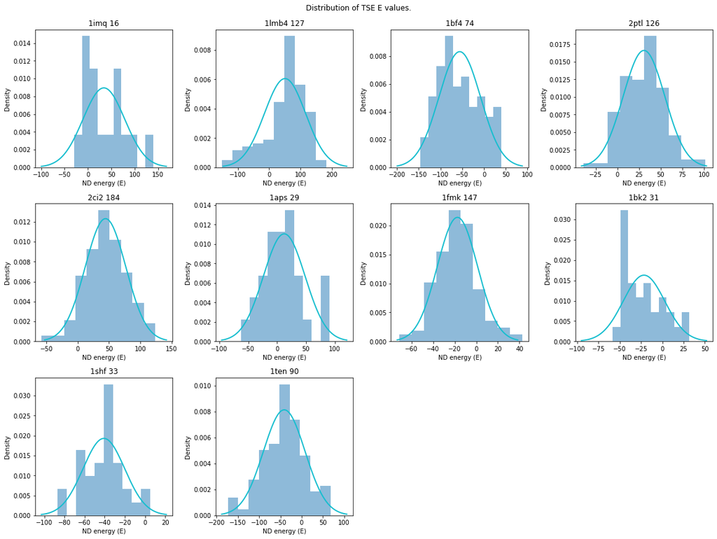

```python
fig, axes = plt.subplots(3, 4, figsize=(16, 12), constrained_layout=True)
plt.suptitle('Distribution of TSE E values.')
plt.delaxes(axes[2, 2])
plt.delaxes(axes[2, 3])

for i, pid in enumerate(PIDs):
    r = i // 4; c = i % 4; ax = axes[r,c]
    plot_TSE(ax, pid)

# plt.savefig("TSE_energydist.png")
```

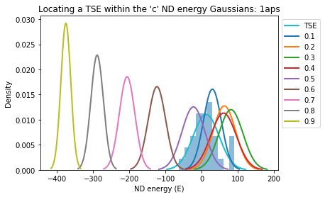

```python
# Plot a TSE ND energy histogram and Gaussian
pid = '1aps'
tse_Es = TSE_stats[pid].scMJE.values
tse_mu, tse_stdev = TSE_mje_params[pid]
plt.hist(tse_Es, density=True, alpha=0.5)
x_axis = np.linspace(tse_mu - 3*tse_stdev, tse_mu + 3*tse_stdev, 1000)
plt.plot(x_axis, norm.pdf(x_axis, tse_mu, tse_stdev), colors[9], lw=2, label='TSE')

# Plot 'c' ND energy Gaussians
for i, q in enumerate(nd.Qs[:-1]):
    mu, stdev = c_mje_params[pid, q]
    x_axis = np.linspace(mu - 3*stdev, mu + 3*stdev, 1000)
    plt.plot(x_axis, norm.pdf(x_axis, mu, stdev), colors[i], lw=2, label=str(q))

plt.title("Locating a TSE within the 'c' ND energy Gaussians: " + pid);
plt.xlabel("ND energy (E)"); plt.ylabel('Density')
_= plt.legend(loc="upper left", bbox_to_anchor=(1.0,1.0))
```

### Approach 1

- Perform KS goodness-of-fit test between TSE $E$ (empirical) distribution, and model $E$ (cumulative) distribution for each $Q$.
- Choose the $Q$ that produces the smallest test statistic (largest p-value, cannot reject null hypothesis).

```python
pid = '1aps'
tse_Es = TSE_stats[pid].scMJE.values
for q in nd.Qs:
    print(q, kstest(tse_Es, 'norm', args=(c_mje_params[pid, q])))
```

```
0.1 KstestResult(statistic=0.3044893063555526, pvalue=0.006973983408850972)
0.2 KstestResult(statistic=0.6321489920964047, pvalue=9.244124623211552e-12)
0.3 KstestResult(statistic=0.7526739082840073, pvalue=1.5376520401168518e-17)
0.4 KstestResult(statistic=0.5850682881726833, pvalue=5.730274685506459e-10)
0.5 KstestResult(statistic=0.448900075269732, pvalue=7.506894373780395e-06)
0.6 KstestResult(statistic=0.9942556309535342, pvalue=2.0847676652966233e-65)
0.7 KstestResult(statistic=0.9999999999867851, pvalue=6.48421526e-316)
0.8 KstestResult(statistic=1.0, pvalue=0.0)
0.9 KstestResult(statistic=1.0, pvalue=0.0)
1.0 KstestResult(statistic=1.0, pvalue=0.0)
```

- For '1aps' TSE, the best-fit 'c' ND energy Gaussian according to the KS test is at $Q=0.1$.

```python
def locate_TSE_E1(nd_mje_params: dict):
    n = len(PIDs)
    TSE_Qs = np.zeros(n); max_pvals = np.zeros(n)
    for i, pid in enumerate(PIDs):
        mjes = TSE_stats[pid].scMJE.values
        ks = [ kstest(mjes, 'norm', args=(nd_mje_params[pid, q])) for q in nd.Qs ]
        d, pval = zip(* ks)
        # print(d, np.min(d))
        # print(pval, np.max(pval))
        max_pvals[i] = np.max(pval)
        n = np.argmax(pval); assert np.argmin(d) == n, "argmin(d) is not equal argmax(pval)"
        TSE_Qs[i] = nd.Qs[n]
    return TSE_Qs, max_pvals
```

```python
c_TSE_Qs_E1, c_pvals_E1 = locate_TSE_E1(c_mje_params.copy())
x_TSE_Qs_E1, x_pvals_E1 = locate_TSE_E1(x_mje_params.copy())
r_TSE_Qs_E1, r_pvals_E1 = locate_TSE_E1(r_mje_params.copy())
```

```python
print(PIDs)
print('c', c_TSE_Qs_E1, np.mean(c_TSE_Qs_E1), np.std(c_TSE_Qs_E1))
print('x', x_TSE_Qs_E1, np.mean(x_TSE_Qs_E1), np.std(x_TSE_Qs_E1))
print('r', r_TSE_Qs_E1, np.mean(r_TSE_Qs_E1), np.std(r_TSE_Qs_E1))
```

```
['1imq', '1lmb4', '1bf4', '2ptl', '2ci2', '1aps', '1fmk', '1bk2', '1shf', '1ten']
c [0.3 0.3 0.7 0.2 0.2 0.1 0.5 0.4 0.6 0.5] 0.38 0.18330302779823363
x [0.3 0.4 0.7 0.3 0.3 0.1 0.5 0.4 0.6 0.5] 0.41 0.16401219466856723
r [0.4 0.2 0.6 0.4 0.2 0.4 0.4 0.4 0.5 0.4] 0.39 0.11357816691600546
```

```python
# Mean Absolute Difference: how close are the TSE Qs to ND peak Qs
print('c:', nd.mad(c_peakQs, c_TSE_Qs_E1))
print('x:', nd.mad(x_peakQs, x_TSE_Qs_E1))
print('r:', nd.mad(r_peakQs, r_TSE_Qs_E1))
```

```
c: 0.19999999999999998
x: 0.19999999999999998
r: 0.2
```

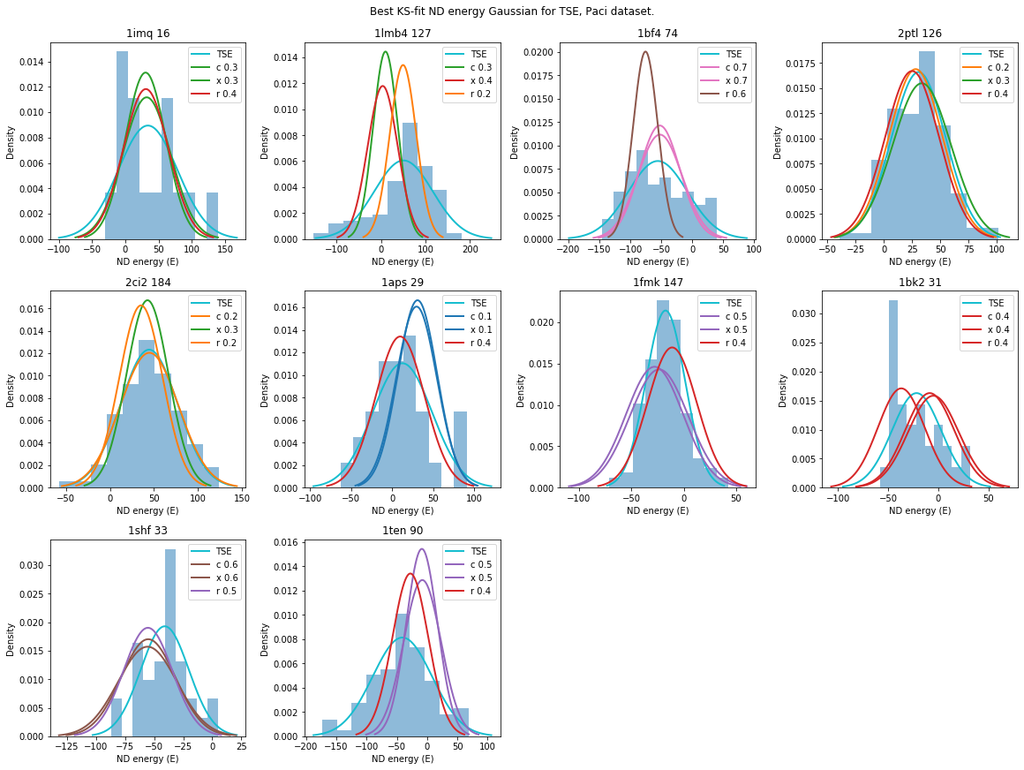

```python
fig, axes = plt.subplots(3, 4, figsize=(16, 12), constrained_layout=True)
plt.suptitle('Best KS-fit ND energy Gaussian for TSE, Paci dataset.')
plt.delaxes(axes[2, 2])
plt.delaxes(axes[2, 3])

for i, pid in enumerate(PIDs):
    r = i//4; c = i%4; ax = axes[r, c]
    plot_TSE(ax, pid)
    c_q = c_TSE_Qs_E1[i]
    plot_ND(ax, pid, c_q, c_mje_params.copy(), 'c')
    x_q = x_TSE_Qs_E1[i]
    plot_ND(ax, pid, x_q, x_mje_params.copy(), 'x')
    r_q = r_TSE_Qs_E1[i]
    plot_ND(ax, pid, r_q, r_mje_params.copy(), 'r')
    ax.legend()

# plt.savefig("TSE_energylocation_Approach1.png")
```

### Approach 2

```python
pid = '1aps'
mjes = TSE_stats[pid].scMJE.values

E_params = [ x_mje_params[pid, q] for q in nd.Qs ]
llhs = np.zeros(10) # log likelihoods, one for each ND energy Gaussian
for q in np.arange(10):
    m, s = E_params[q]
    dens = [ norm.pdf(x, m, s) for x in mjes ]
    llhs[q] = logsumexp(dens)
    print(nd.Qs[q], np.round(llhs[q], 4))
    # can ignore priors: uniform, each Q has the same prob.
    # denom = np.sum(llhs) # can ignore normalizing factor
    # post_probs = llhs/denom # np.sum(post_probs) approx. 1.0
    # posteriors[pid] = post_probs

q = nd.Qs[np.argmax(llhs)] # MAP q
print(pid, "MAP Q:", q)
```

```
0.1 3.3757
0.2 3.3714
0.3 3.3697
0.4 3.3713
0.5 3.3739
0.6 3.3673
0.7 3.3673
0.8 3.3673
0.9 3.3673
1.0 3.3673
1aps MAP Q: 0.1
```

```python
# joint prob/density of the sample of i.i.d. observations
def locate_TSE_E2(nd_mje_params: dict):
    n = len(PIDs); TSE_Qs = np.zeros(n)
    for i, pid in enumerate(PIDs):
        mjes = TSE_stats[pid].scMJE.values
        E_params = [ nd_mje_params[pid, q] for q in nd.Qs ]
        llhs = np.zeros(10) # log likelihoods, one for each ND energy Gaussian
        for q in np.arange(10):
            m, s = E_params[q]
            dens = [ norm.pdf(x, m, s) for x in mjes ]
            llhs[q] = logsumexp(dens)
        q = nd.Qs[np.argmax(llhs)] # maximum likelihood
        TSE_Qs[i] = q
    return TSE_Qs
```

```python
c_TSE_Qs_E2 = locate_TSE_E2(c_mje_params.copy())
x_TSE_Qs_E2 = locate_TSE_E2(x_mje_params.copy())
r_TSE_Qs_E2 = locate_TSE_E2(r_mje_params.copy())

print(PIDs)
print('c', c_TSE_Qs_E2, np.mean(c_TSE_Qs_E2), np.std(c_TSE_Qs_E2))
print('x', x_TSE_Qs_E2, np.mean(x_TSE_Qs_E2), np.std(x_TSE_Qs_E2))
print('r', r_TSE_Qs_E2, np.mean(r_TSE_Qs_E2), np.std(r_TSE_Qs_E2))
```

```
['1imq', '1lmb4', '1bf4', '2ptl', '2ci2', '1aps', '1fmk', '1bk2', '1shf', '1ten']
c [0.1 0.3 0.7 0.2 0.1 0.1 0.5 0.4 0.6 0.5] 0.35 0.21095023109728986
x [0.1 0.4 0.7 0.2 0.3 0.1 0.5 0.5 0.6 0.5] 0.39 0.19723082923316018
r [0.4 0.2 0.6 0.4 0.1 0.4 0.4 0.4 0.5 0.4] 0.38 0.132664991614216
```

```python
# Mean Absolute Difference: how close are the estimated Qs for PTS nets to ND peak Qs
print('c:', nd.mad(c_peakQs, c_TSE_Qs_E2))
print('x:', nd.mad(x_peakQs, x_TSE_Qs_E2))
print('r:', nd.mad(r_peakQs, r_TSE_Qs_E2))
```

```
c: 0.21000000000000002
x: 0.21999999999999997
r: 0.21000000000000002
```

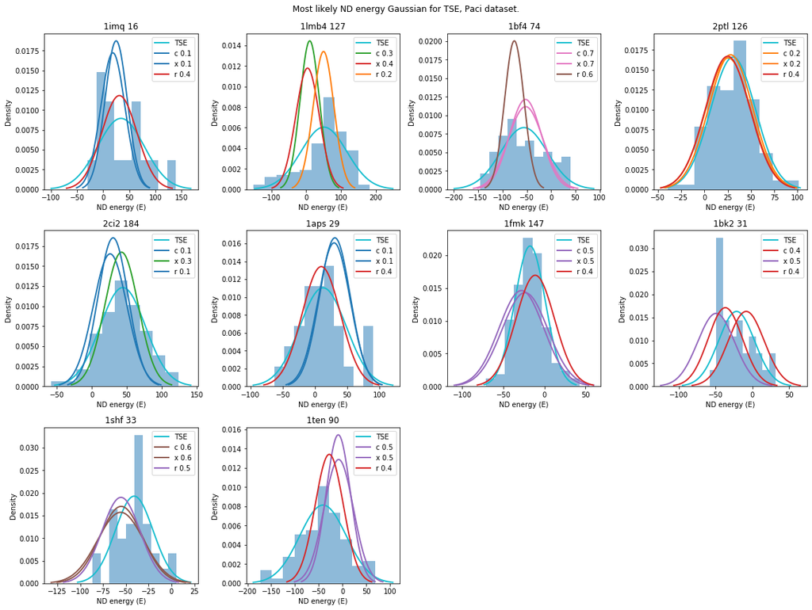

```python
fig, axes = plt.subplots(3, 4, figsize=(16, 12), constrained_layout=True)
plt.suptitle('Most likely ND energy Gaussian for TSE, Paci dataset.')
plt.delaxes(axes[2, 2])
plt.delaxes(axes[2, 3])

for i, pid in enumerate(PIDs):
    r = i//4; c = i%4; ax = axes[r, c]
    plot_TSE(ax, pid)
    c_q = c_TSE_Qs_E2[i]
    plot_ND(ax, pid, c_q, c_mje_params.copy(), 'c')
    x_q = x_TSE_Qs_E2[i]
    plot_ND(ax, pid, x_q, x_mje_params.copy(), 'x')
    r_q = r_TSE_Qs_E2[i]
    plot_ND(ax, pid, r_q, r_mje_params.copy(), 'r')
    ax.legend()

# plt.savefig("TSE_energylocation_Approach2.png")
```

#### Compare TSE Qs selected by Approach 1 and 2.

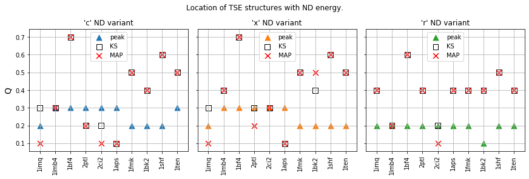

```python
# plot ND_peak_Qs, TSE_Qs_E1, TSE_Qs_E2
fig, axes = plt.subplots(1, 3, figsize=(12, 4), constrained_layout=True, sharey=True)
fig.suptitle("Location of TSE structures with ND energy.")

ax = axes[0]
ax.scatter(PIDs, c_peakQs, marker='^', s=80, color='tab:blue', label='peak')
ax.scatter(PIDs, c_TSE_Qs_E1, marker='s', s=80, edgecolors='black', facecolors='none',
           label='KS')
ax.scatter(PIDs, c_TSE_Qs_E2, marker='x', s=80, color='red', label='MAP')
ax.set_title("'c' ND variant")
ax.set_xticklabels(PIDs, rotation=90); ax.set_ylabel('Q', fontsize=14)
ax.legend(loc="upper center"); ax.grid()

ax = axes[1]
ax.scatter(PIDs, x_peakQs, marker='^', s=80, color='tab:orange', label='peak')
ax.scatter(PIDs, x_TSE_Qs_E1, marker='s', s=80, edgecolors='black', facecolors='none',
           label='KS')
ax.scatter(PIDs, x_TSE_Qs_E2, marker='x', s=80, color='red', label='MAP')
ax.set_title("'x' ND variant")
ax.set_xticklabels(PIDs, rotation=90)
ax.legend(loc="upper center"); ax.grid()

ax = axes[2]
ax.scatter(PIDs, r_peakQs, marker='^', s=80, color='tab:green', label='peak')
ax.scatter(PIDs, r_TSE_Qs_E1, marker='s', s=80, edgecolors='black', facecolors='none',
           label='KS')
ax.scatter(PIDs, r_TSE_Qs_E2, marker='x', s=80, color='red', label='MAP')
ax.set_title("'r' ND variant")
ax.set_xticklabels(PIDs, rotation=90)
ax.legend(loc="upper center"); ax.grid()
```

- Approaches 1 and 2 pick the same $Q$ for most TSEs.

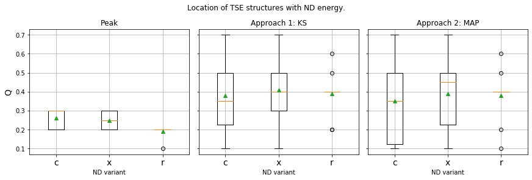

```python
# boxplot ND_peak_Qs, TSE_Qs_E1, TSE_Qs_E2
fig, axes = plt.subplots(1, 3, figsize=(12, 4), constrained_layout=True, sharey=True)
fig.suptitle("Location of TSE structures with ND energy.")

ax = axes[0]
ax.boxplot([c_peakQs, x_peakQs, r_peakQs], showmeans=True)
ax.set_title("Peak")
ax.set_xlabel("ND variant"); ax.set_xticklabels(['c', 'x', 'r'], fontsize=14)
ax.set_ylabel('Q', fontsize=14); ax.set_yticks(nd.Qs)
ax.grid()

ax = axes[1]
ax.boxplot([c_TSE_Qs_E1, x_TSE_Qs_E1, r_TSE_Qs_E1], showmeans=True)
ax.set_title("Approach 1: KS")
ax.set_xlabel("ND variant"); ax.set_xticklabels(['c', 'x', 'r'], fontsize=14)
# ax.set_ylabel('Q', fontsize=14); ax.set_yticks(nd.Qs);
ax.grid()

ax = axes[2]
ax.boxplot([c_TSE_Qs_E2, x_TSE_Qs_E2, r_TSE_Qs_E2], showmeans=True)
ax.set_title("Approach 2: MAP")
ax.set_xlabel("ND variant"); ax.set_xticklabels(['c', 'x', 'r'], fontsize=14)
# ax.set_ylabel('Q', fontsize=14); ax.set_yticks(nd.Qs);
ax.grid()
```

## End of notebook

SKLC September 2020